# Increasing Diagnostic Accuracy for Breast Cancer

# Potential Solution: SVMs

I looked into some additional resources to read more about the current state of this research. I found a really awesome paper on feature extraction and classification. Specifically, it is called “Analysis of Feature Extraction and Classification Methods on Histopathological Images for Diagnosing Invasive Ductal Carcinoma” which was presented within the 2022 International Conference on Information Technology, Computer and Electrical Engineering. This project has some similarities with my chosen data set, as their methodology also utilized histopathology images as well (tissue images). They used some more complex feature extraction techniques and then classified the results using the Support Vector Machine. They had great results with SVM, so I tried that model on our data set to see if we could do even better!

```r
library(e1071)
c_recipe <- recipe(diagnosis~., data=cancer_data_test)%>%
  step_dummy(all_nominal_predictors()) %>%
  step_center(all_numeric_predictors()) %>%
  step_scale(all_numeric_predictors()) %>%
  step_pca()

c_recipe  %>% prep() %>% bake(new_data=cancer_data_test)
```

```
## # A tibble: 115 × 32
##        id radius_mean texture_mean perimeter_mean area_mean smoothness_mean
##     <dbl>       <dbl>        <dbl>          <dbl>     <dbl>           <dbl>
##  1 -0.200      1.20          1.15          1.39      1.06          -0.00504
##  2 -0.200      0.321         0.967         0.301     0.198         -0.987
##  3  0.799     -0.238         0.678        -0.0815   -0.321          1.15
##  4 -0.200      0.0123        0.141        -0.0384   -0.0517         0.0881
##  5 -0.109     -1.35         -1.52         -1.34     -1.09           0.362
##  6 -0.200      0.662        -0.666         0.766     0.527          1.55
##  7 -0.200      0.775        -0.958         0.728     0.635          0.0734
##  8  0.810     -0.386         0.505        -0.391    -0.440         -0.0241
##  9 -0.200      1.06         -0.406         1.06      0.942          0.912
## 10 -0.200     -0.682        -1.05         -0.670    -0.649          0.413
## # ℹ 105 more rows
## # ℹ 26 more variables: compactness_mean <dbl>, concavity_mean <dbl>,
## #   `concave points_mean` <dbl>, symmetry_mean <dbl>,
## #   fractal_dimension_mean <dbl>, radius_se <dbl>, texture_se <dbl>,
## #   perimeter_se <dbl>, area_se <dbl>, smoothness_se <dbl>,
## #   compactness_se <dbl>, concavity_se <dbl>, `concave points_se` <dbl>,
## #   symmetry_se <dbl>, fractal_dimension_se <dbl>, radius_worst <dbl>, …
```

```r
svm_fit <- svm(diagnosis~.,
                  data = cancer_data_test, kernal = "polynomial")
svm_predictions <- predict(svm_fit, cancer_data_test)
```

```r
library(pROC)
cancer_data_test$diagnosis = as.factor(cancer_data_test$diagnosis)
library(caret)
predictions <- predict(svm_fit, cancer_data_test)
confusionMatrix(predictions, cancer_data_test$diagnosis)
```

```
## Confusion Matrix and Statistics
##
##           Reference
## Prediction  B  M
##          B 72  1
##          M  0 42
##
##                Accuracy : 0.9913
##                  95% CI : (0.9525, 0.9998)
##     No Information Rate : 0.6261
##     P-Value [Acc > NIR] : <2e-16
##
##                   Kappa : 0.9813
##
##  Mcnemar's Test P-Value : 1
##
##             Sensitivity : 1.0000
##             Specificity : 0.9767
##          Pos Pred Value : 0.9863
##          Neg Pred Value : 1.0000
##              Prevalence : 0.6261
##          Detection Rate : 0.6261
##    Detection Prevalence : 0.6348
##       Balanced Accuracy : 0.9884
##
##        'Positive' Class : B
##
```

Looking at the No Information Rate value, it 0.6261, indicating that if we just always guessed the majority class benign, we would be accurate 62.61% of the time.

SVMs are hard to visualize past 2 dimensions, so I decided to plot the decision boundary to explore our earlier research question.

Here we will explore the previous idea we touched on: Interesting Pattern in Correation Between Predictors and Chances of Malignancy. Referencing back to our unexpected outcome that in the mean correlation plot, the mean fractal dimension, mean radius, mean perimeter, and mean area all have a somewhat negatively correlated relationship (roughly -0.4 to -0.5). However, in the correlation plot with the worst measurements, however, the relationship between the two variables is approximately 0.

It could be that a somewhat negatively correlated relationship between the above values is a good indication that the tumor is most likely not malignant. Let’s investigate this relationship with our best model! In the SVM plot, I used the mean fractal dimension and mean concave points as my two selected variables to see how these predictors affect diagnoses!

```r
library(kernlab)
cancer_data_test
```

```
## # A tibble: 115 × 32
##          id diagnosis radius_mean texture_mean perimeter_mean area_mean
##       <dbl> <fct>           <dbl>        <dbl>          <dbl>     <dbl>
##  1   846226 M               19.2          24.8          132.      1123
##  2   846381 M               15.8          24.0          104.       783.
##  3 84667401 M               13.7          22.6           93.6      578.
##  4   848406 M               14.7          20.1           94.7      684.
##  5  8510824 B                9.50         12.4           60.3      274.
##  6   852631 M               17.1          16.4          116        913.
##  7   853201 M               17.6          15.0          115        955.
##  8 85638502 M               13.2          21.8           85.4      532.
##  9   857010 M               18.6          17.6          124.      1076
## 10   857155 B               12.0          14.6           78.0      449.
## # ℹ 105 more rows
## # ℹ 26 more variables: smoothness_mean <dbl>, compactness_mean <dbl>,
## #   concavity_mean <dbl>, `concave points_mean` <dbl>, symmetry_mean <dbl>,
## #   fractal_dimension_mean <dbl>, radius_se <dbl>, texture_se <dbl>,
## #   perimeter_se <dbl>, area_se <dbl>, smoothness_se <dbl>,
## #   compactness_se <dbl>, concavity_se <dbl>, `concave points_se` <dbl>,
## #   symmetry_se <dbl>, fractal_dimension_se <dbl>, radius_worst <dbl>, …
```

```r
x1 <- cancer_data_test$fractal_dimension_mean
x2 <- cancer_data_test$'concave points_mean'

diagnosis<- as.factor(cancer_data_test$diagnosis)
data <- data.frame(x1 = x1, x2 = x2)
cancer_data_test
```

```
## # A tibble: 115 × 32
##          id diagnosis radius_mean texture_mean perimeter_mean area_mean
##       <dbl> <fct>           <dbl>        <dbl>          <dbl>     <dbl>
##  1   846226 M               19.2          24.8          132.      1123
##  2   846381 M               15.8          24.0          104.       783.
##  3 84667401 M               13.7          22.6           93.6      578.
##  4   848406 M               14.7          20.1           94.7      684.
##  5  8510824 B                9.50         12.4           60.3      274.
##  6   852631 M               17.1          16.4          116        913.
##  7   853201 M               17.6          15.0          115        955.
##  8 85638502 M               13.2          21.8           85.4      532.
##  9   857010 M               18.6          17.6          124.      1076
## 10   857155 B               12.0          14.6           78.0      449.
## # ℹ 105 more rows
## # ℹ 26 more variables: smoothness_mean <dbl>, compactness_mean <dbl>,
## #   concavity_mean <dbl>, `concave points_mean` <dbl>, symmetry_mean <dbl>,
## #   fractal_dimension_mean <dbl>, radius_se <dbl>, texture_se <dbl>,
## #   perimeter_se <dbl>, area_se <dbl>, smoothness_se <dbl>,
## #   compactness_se <dbl>, concavity_se <dbl>, `concave points_se` <dbl>,
## #   symmetry_se <dbl>, fractal_dimension_se <dbl>, radius_worst <dbl>, …
```

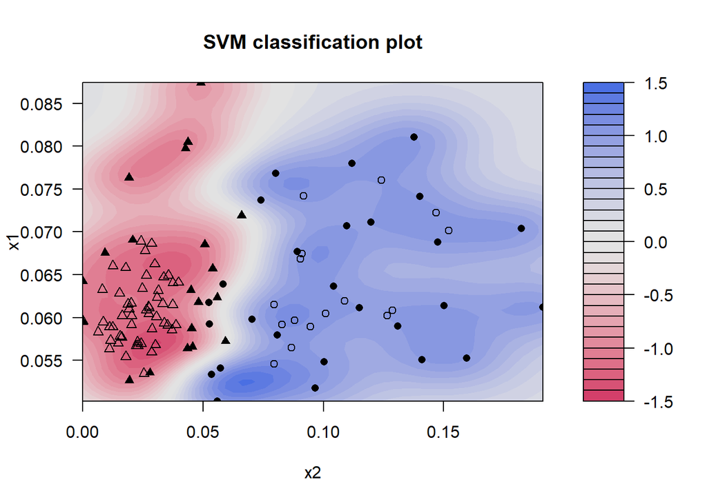

```r
svm_fit <- ksvm(diagnosis~., data= data)
plot(svm_fit, data = cancer_data_test)
```

Here we see that SVM does a great job, as there is a clear red and blue boundary. The SVM is unique in it’s ability as it is the only linear model that can classify data which isn’t linearly separable. Here we see the red and blue groups are definitely not separated by a straight line, but SVM still did a great job. It seems that after values of 0.05 for concave points mean, it is very likely that the tumor is malignant.